# Graficar en R (bias genético)

### Agregar puntos a un mapa

Es muy común tener las coordenadas x,y de nuestros puntos de muestreo en un archivo junto con el resto de la info de nuestras muestras. Por ejemplo en el caso de la info de maíces que hemos estado utilizando:

```r
fullmat[1:5,c("Latitud", "Longitud")]
```

```
##    Latitud   Longitud
## 1 28.68578 -107.58300
## 2 19.29083  -97.92944
## 3 28.53703 -108.92467
## 4 16.03225  -92.97972
## 5 20.09111 -101.11889
```

Agregar esta info a un mapa **en la misma proyección y sistema de coordenadas** puede hacerse con la función `points`:

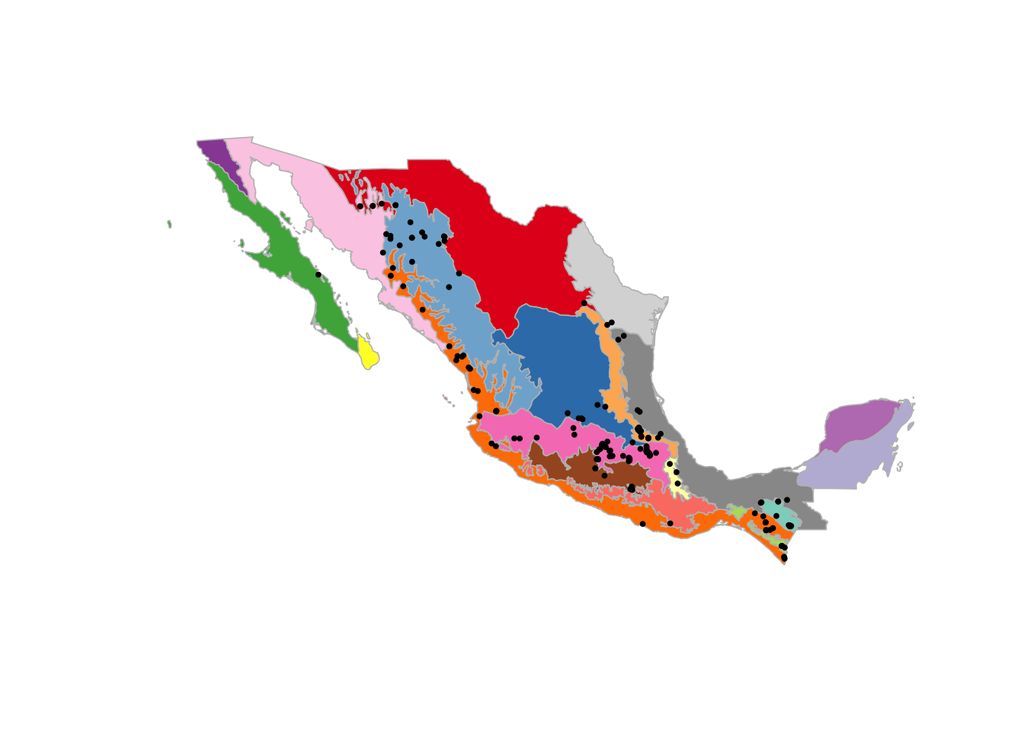

```r
# plot map
plot(biogeo, border="grey", col=biogeo$PROVINCIA, lwd=0.8)
# agregar puntos
points(fullmat$Longitud, fullmat$Latitud, pch=19, col="black", cex=0.4)
```

**Ejercicio**: Baja un mapa (nivel nacional) que te interese del [GeoPortal de la CONABIO](http://www.conabio.gob.mx/informacion/gis/), ploteálo y agrega los puntos del muestro de maíz, utilizando una forma de punto diferente para los teocintles, y que los puntos estén coloreados por CategAltitud.

## Heatmaps en R

Los *heatmaps* son gráficos bastánte útiles para resumir de manera visual una gran cantidad de datos que queremos contrastar (e.g., Diferenciación genética entre poblaciones, Composición de comunidades biológicas, niveles de expresión en diferentes tejidos, etc.). En R, una librería bastante útil para construir heatmaps es [Heatplus](http://bioconductor.org/packages/release/bioc/html/Heatplus.html), misma que vive en Bioconductor. Para explorar las funciones básicas de esta paquetería, lleva a cabo el tutorial de [The Molecular Ecologist](http://www.molecularecologist.com/2013/08/making-heatmaps-with-r-for-microbiome-analysis/).

Ojo, antes de empezar, necesitaremos tener las siguientes librerías instaladas

```
library(gplots)
library(vegan)
library(RColorBrewer)
```

Para instalar y llamar a Heatplus:

```
source("http://bioconductor.org/biocLite.R") #Hacer un source
biocLite("Heatplus") #Compilar
library(Heatplus) #Llamar a la librería
```

## Guardar imágenes:

### Método 1:

- “Abrir un device” con `png()`, `jpg()`, `pdf()` según el formato en que queramos guardar.
- Hacer la gráfica
- “Cerrar el device” con `dev.off`

```r
png("PracUni3/maices/out/arbol.png")
plot(maiz.tree, type="unrooted", show.tip=FALSE)
tiplabels(pch=20, col="green3", tip=c(1:161), cex=.5)
tiplabels(pch=15, col="black", tip=c(162:165), cex=.5)
dev.off()
```

Si incluyes esto cuando corras tu script remotamente (eg en un cluster), las gráficas se guardarán con los nombres que les digas y en el directorio que especifiques :)

### Método 2:

En R studio darle “Export” o “Copy” en el panel de la imagen y seleccionar un nombre de archivo y demás características.